# Тестовое задание на соискание должности исследователя "Белка Диджитал"

# Задача 2

На основе данных собранных в задании 1 разбить исходную выборку на кластеры методами кластерного анализа. Цель задания определить район продажи квартиры на основе данных о ценах, площадях и количестве комнат. Сравнить полученный результат с реальным расположением квартир по районам. В качестве района рассматривать Ленинский, Орджоникидзевский, Правобережный, Орджоникидзевский (Левый берег) и Ленинский (левый берег).

```python
data_cl = data.drop(['region'], axis=1)
```

```python
distortion = []
K = range(1, 15)
for k in K:
    model = KMeans(n_clusters=k, n_init=10, random_state=RANDOM_STATE)
    model.fit(data_cl)
    distortion.append(model.inertia_)
```

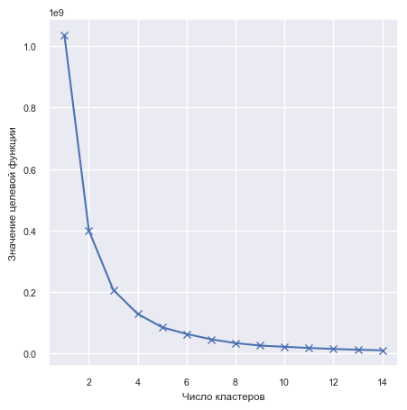

```python
plt.figure(figsize=(5, 5))
plt.plot(K, distortion, 'bx-')
plt.xlabel('Число кластеров')
plt.ylabel('Значение целевой функции')
plt.show()
```

Согласно графику можно сказать, что число кластеров начиная с 4 является оптимальным. Поэтому можем смело задавать число кластеров равным 5.

```python
model = KMeans(n_clusters=5, n_init=10, random_state=RANDOM_STATE)
```

```python
model.fit(data_cl)
```

```
KMeans(n_clusters=5, n_init=10, random_state=100923)
```

```python
centroids = pd.DataFrame(model.cluster_centers_, columns=data_cl.columns)
data_cl['label'] = model.labels_.astype(str)
centroids['label'] = ['0 centroid', '1 centroid', '2 centroid', '3 centroid', '4 centroid']
data_all = pd.concat([data_cl, centroids], ignore_index=True)
```

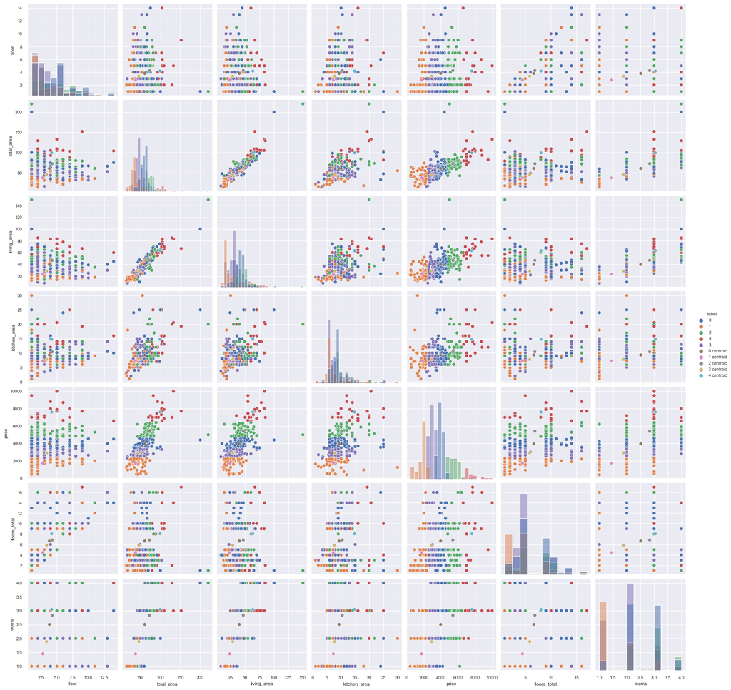

```python
pairgrid = sns.pairplot(data_all, hue='label', diag_kind='hist')
```

Получившиеся разделения на кластеры наиболее заметны на графиках *total_area / price*, *living_area / price*, *kitchen_area / price*. Графики *living_area / price* и *kitchen_area / price* являются производными от *total_area / price*. Потому что, *living_area* и *kitchen_area* находятся к *total_area* в некотором близком к константному отношению. Поэтому рассмотрим только график *total_area / price* ислючим лишние признаки

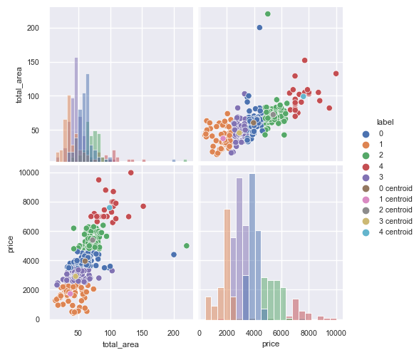

```python
pairgrid = sns.pairplot(
    data_all.drop(['floor', 'floors_total', 'rooms', 'living_area', 'kitchen_area'], axis=1),
    hue='label',
    diag_kind='hist'
)
```

Анализируя график можно сказать, что кластеры распределены по премиальности квартиры. Сравним как в действительности распределены районы продажи квартира.

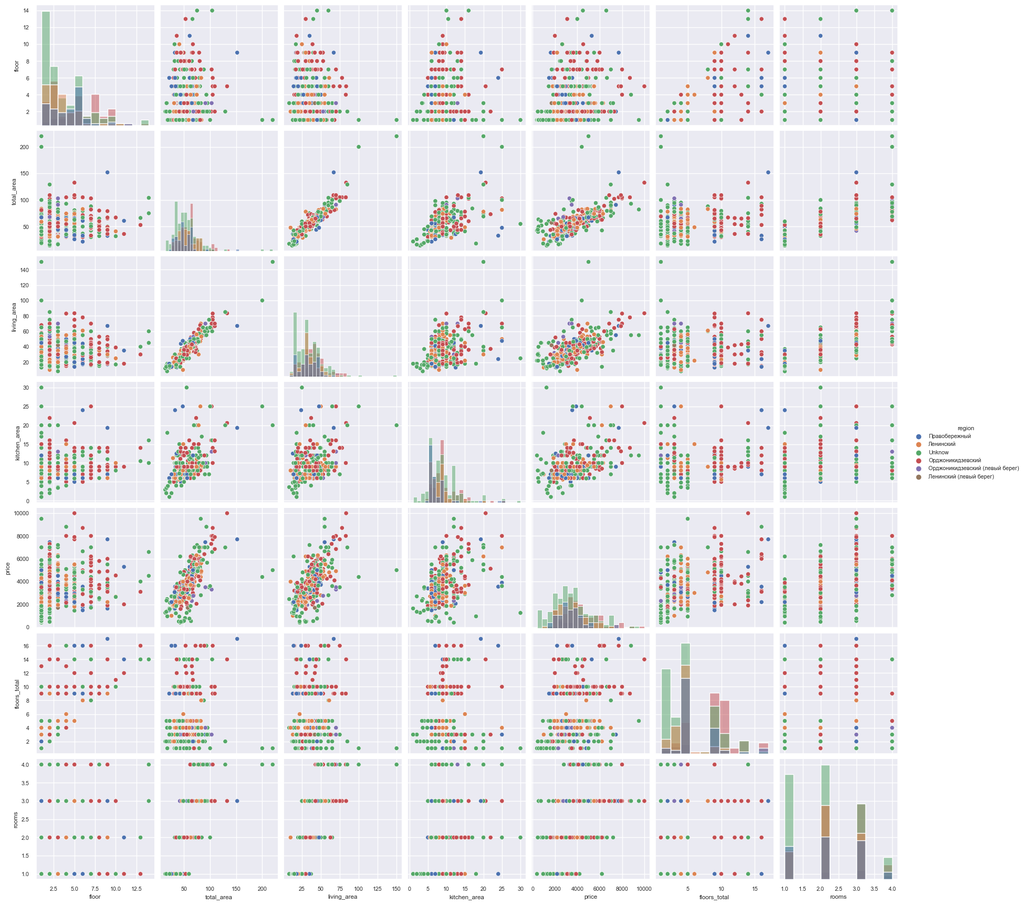

```python
pairgrid = sns.pairplot(data, hue='region', diag_kind='hist')
```

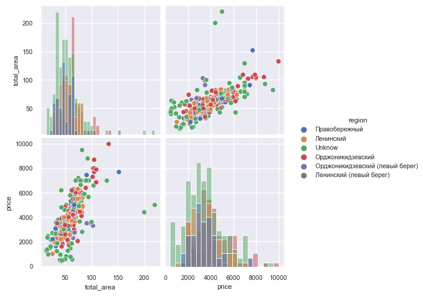

```python
pairgrid = sns.pairplot(
    data.drop(['floor', 'floors_total', 'rooms', 'living_area', 'kitchen_area'], axis=1),
    hue='region',
    diag_kind='hist'
)
```

Можно заметить, что выраженной границы по распределению районов по данным не прослеживается. Поэтому, к сожалению, не получается распределить и кластеры по данным аналогично районам.